# Practical Machine Learning

Gina Pham

## Read Data

Read data from the PML course into memory.

```r
setwd("/Users/gpham/OneDrive - Pairwise Plants, LLC/Data Science/Practical Machine Learning/")

library(dplyr)
library(caret)
library(tidyverse)

train <- read_csv("pml-training.csv")
```

```r
test <- read_csv("pml-testing.csv")
```

## Clean data to remove NAs

There are several columns containing missing data. This section removes the columns. This leaves 60 columns in train_clean with 19,622 measurements.

```r
train_clean <- train[,!(apply(train, 2, is.na) %>%
                          colSums != 0)]
test_clean <- test[,!(apply(test, 2, is.na) %>%
                        colSums !=0)]
dim(train_clean)
```

```
[1] 19622    60
```

## Remove metadata that are not predictors

Removing some uninformative values in the matrix further reduces the number of columns to 53.

```r
train_clean <- train_clean[-c(1:7)]

test_clean <- test_clean[-c(1:7)]
```

## Create training and testing data sets from train set

This section partitions the data and uses 75% for training.

```r
set.seed(13245)
inTrain <- createDataPartition(y = train_clean$classe,
                               p = 0.75,
                               list = FALSE)
trainData <- train_clean[inTrain,]
testData <- train_clean[-inTrain,]
```

## Explore the data to check for highly correlated variables

```r
# find pairs of predictors with correlation of at least 0.8.
M <- abs(cor(trainData[,-46]))
diag(M) <- 0
which(M > 0.8, arr.ind = TRUE)
```

```
                 row col
magnet_belt_x      4   1
accel_belt_z       3   2
accel_belt_y       2   3
accel_belt_x       1   4
gyros_arm_y       12  11
gyros_arm_x       11  12
magnet_arm_x      17  14
accel_arm_x       14  17
magnet_arm_z      19  18
magnet_arm_y      18  19
accel_dumbbell_x  27  21
accel_dumbbell_z  29  22
gyros_dumbbell_z  26  24
gyros_forearm_z   39  24
gyros_dumbbell_x  24  26
gyros_forearm_z   39  26
pitch_dumbbell    21  27
yaw_dumbbell      22  29
gyros_forearm_z   39  38
gyros_dumbbell_x  24  39
gyros_dumbbell_z  26  39
gyros_forearm_y   38  39
```

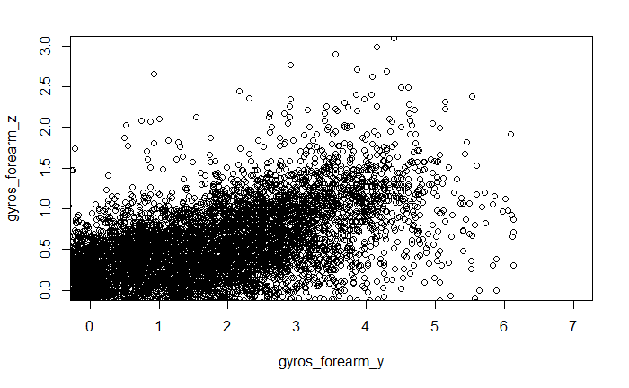

```r
# example of correlated values for gyros_forearm_y and gyros_forearm_z
plot(trainData[,38:39], ylim = c(0,3), xlim = c(0,7))
```

This figure shows a summary of correlated predictors. The ‘gyros_dumbbell’ values show particularly strong correlation.

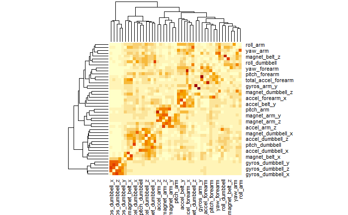

```r
heatmap(M)
```

## Train Naive Bayes model w/ 5-fold cross validation

Naive Bayes trains the model quickly, but has low prediction accuracy of 0.7176. In this model, the predictors are assumed to be independent of one another. This may explain the somewhat low accuracy as evidenced by high out-of-sample errors.

```r
confusionMatrix(nb_predictions, testData$classe %>% as.factor)
```

```
Confusion Matrix and Statistics

          Reference
Prediction    A    B    C    D    E
         A 1241  217  209  133   68
         B    9  559   63    9   87
         C   43   90  540   84   58
         D   83   62   37  539   48
         E   19   21    6   39  640

Overall Statistics

               Accuracy : 0.7176
                 95% CI : (0.7047, 0.7301)
    No Information Rate : 0.2845
    P-Value [Acc > NIR] : < 2.2e-16

                  Kappa : 0.6384

 Mcnemar's Test P-Value : < 2.2e-16

Statistics by Class:

                     Class: A Class: B Class: C Class: D Class: E
Sensitivity            0.8896   0.5890   0.6316   0.6704   0.7103
Specificity            0.8213   0.9575   0.9321   0.9439   0.9788
Pos Pred Value         0.6643   0.7689   0.6626   0.7009   0.8828
Neg Pred Value         0.9493   0.9066   0.9230   0.9359   0.9375
Prevalence             0.2845   0.1935   0.1743   0.1639   0.1837
Detection Rate         0.2531   0.1140   0.1101   0.1099   0.1305
Detection Prevalence   0.3809   0.1482   0.1662   0.1568   0.1478
Balanced Accuracy      0.8555   0.7733   0.7818   0.8072   0.8445
```

## Train RF model w/ 5-fold cross validation

Random forest shows the best accuracy, though fitting the model is the slowest. (Code has been commented out to save time on re-running the model for report generation). In this case, the proximity matrix is assumed to be symmetrical.

```r
# modFit2 <- train(classe ~ ., data = trainData, method = "rf", trControl = ctrlTrain, prox = TRUE)
# summary(modFit2$finalModel)
# predictionsRF <- predict(object = modFit2, newdata = testData)
# confusionMatrix(predictionsRF, testData$classe %>% as.factor)
```

```r
# modFit2 <- train(classe ~ ., data = trainData, method = "rf", trControl = ctrlTrain, prox = TRUE)
# summary(modFit2$finalModel)
# predictionsRF <- predict(object = modFit2, newdata = testData)
confusionMatrix(predictionsRF, testData$classe %>% as.factor)
```

```
Confusion Matrix and Statistics

          Reference
Prediction    A    B    C    D    E
         A 1394   10    0    0    0
         B    1  938    6    0    1
         C    0    1  847    7    2
         D    0    0    2  796    1
         E    0    0    0    1  897

Overall Statistics

               Accuracy : 0.9935
                 95% CI : (0.9908, 0.9955)
    No Information Rate : 0.2845
    P-Value [Acc > NIR] : < 2.2e-16

                  Kappa : 0.9917

 Mcnemar's Test P-Value : NA

Statistics by Class:

                     Class: A Class: B Class: C Class: D Class: E
Sensitivity            0.9993   0.9884   0.9906   0.9900   0.9956
Specificity            0.9972   0.9980   0.9975   0.9993   0.9998
Pos Pred Value         0.9929   0.9915   0.9883   0.9962   0.9989
Neg Pred Value         0.9997   0.9972   0.9980   0.9981   0.9990
Prevalence             0.2845   0.1935   0.1743   0.1639   0.1837
Detection Rate         0.2843   0.1913   0.1727   0.1623   0.1829
Detection Prevalence   0.2863   0.1929   0.1748   0.1629   0.1831
Balanced Accuracy      0.9982   0.9932   0.9941   0.9947   0.9977
```

Random forest shows high prediction accuracy for all five outcomes:

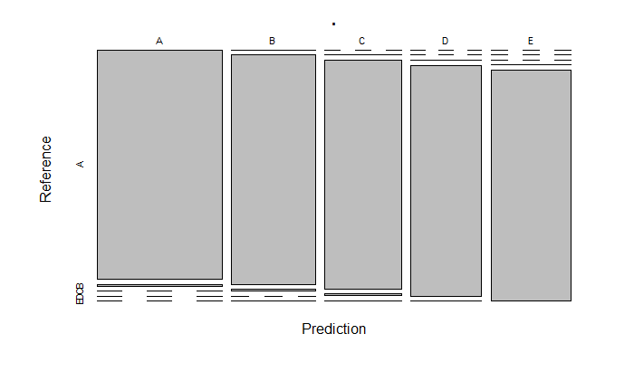

## Train random ferns model w/ 5-fold cross validations

```r
# modFit3 <- train(classe ~ ., data = trainData, method = "rFerns", trControl = ctrlTrain)
# summary(modFit3$finalModel)
# predictionsRFerns <- predict(object = modFit3, newdata = testData)
confusionMatrix(predictionsRFerns, testData$classe %>% as.factor)
```

```
Confusion Matrix and Statistics

          Reference
Prediction    A    B    C    D    E
         A 1247   11    0    0    0
         B   18  833   21    0    0
         C   27   94  819   71   40
         D  101   11   15  732   31
         E    2    0    0    1  830

Overall Statistics

               Accuracy : 0.9097
                 95% CI : (0.9013, 0.9175)
    No Information Rate : 0.2845
    P-Value [Acc > NIR] : < 2.2e-16

                  Kappa : 0.8863

 Mcnemar's Test P-Value : NA

Statistics by Class:

                     Class: A Class: B Class: C Class: D Class: E
Sensitivity            0.8939   0.8778   0.9579   0.9104   0.9212
Specificity            0.9969   0.9901   0.9427   0.9615   0.9993
Pos Pred Value         0.9913   0.9553   0.7793   0.8225   0.9964
Neg Pred Value         0.9594   0.9712   0.9907   0.9821   0.9826
Prevalence             0.2845   0.1935   0.1743   0.1639   0.1837
Detection Rate         0.2543   0.1699   0.1670   0.1493   0.1692
Detection Prevalence   0.2565   0.1778   0.2143   0.1815   0.1699
Balanced Accuracy      0.9454   0.9340   0.9503   0.9360   0.9602
```

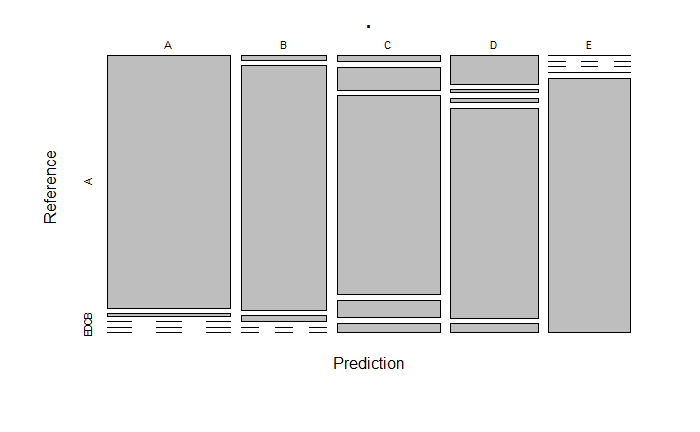

## Fit a model that combines random ferns and Naive Bayes

Creating an ensemble model of random ferns and naive bayes is actually worse than using the random ferns model alone.

```r
confusionMatrix(combPred, as.factor(testData$classe))
```

```
Confusion Matrix and Statistics

          Reference
Prediction    A    B    C    D    E
         A 1245   11    0    0    0
         B   18  833   21    0    0
         C   27   94  819   71   40
         D  101   11   15  732   31
         E    4    0    0    1  830

Overall Statistics

               Accuracy : 0.9093
                 95% CI : (0.9009, 0.9172)
    No Information Rate : 0.2845
    P-Value [Acc > NIR] : < 2.2e-16

                  Kappa : 0.8858

 Mcnemar's Test P-Value : NA

Statistics by Class:

                     Class: A Class: B Class: C Class: D Class: E
Sensitivity            0.8925   0.8778   0.9579   0.9104   0.9212
Specificity            0.9969   0.9901   0.9427   0.9615   0.9988
Pos Pred Value         0.9912   0.9553   0.7793   0.8225   0.9940
Neg Pred Value         0.9589   0.9712   0.9907   0.9821   0.9826
Prevalence             0.2845   0.1935   0.1743   0.1639   0.1837
Detection Rate         0.2539   0.1699   0.1670   0.1493   0.1692
Detection Prevalence   0.2561   0.1778   0.2143   0.1815   0.1703
Balanced Accuracy      0.9447   0.9340   0.9503   0.9360   0.9600
```

## Further evaluation of the importance of variables in the random forest

Because the random forest model was the most accurate, we can do further evaluation to understand the importance assigned to each value in predicting the correct outcomes. This shows that roll_belt is an excellent predictor.

```r
rfVarImp <- varImp(modFit2)
rfVarImpDF <- rfVarImp$importance
rfVarImpDF <- mutate(rfVarImpDF, var = rownames(rfVarImpDF))

rfVarImp
```

```
rf variable importance

  only 20 most important variables shown (out of 52)
```

|  | Overall |
| --- | --- |
| roll_belt | 100.00000 |
| pitch_forearm | 57.65748 |
| yaw_belt | 54.18898 |
| pitch_belt | 44.38185 |
| magnet_dumbbell_y | 44.13921 |
| roll_forearm | 44.00023 |
| magnet_dumbbell_z | 43.03322 |
| accel_dumbbell_y | 22.76809 |
| roll_dumbbell | 17.73544 |
| accel_forearm_x | 17.28630 |

[output cut: 10 more lines]

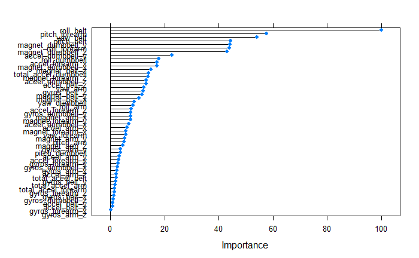

```r
plot(rfVarImp)
```